# K-Nearest Neighbor in R

Created By Julio SOLANO

Nov 05, 2018

# Setup

```r
 set.seed(69069)
```

# Loading Libraries

```r
library(ROCR)           # ROC Curve
library(pROC)           # Plot ROC Curve
library(tidyverse)
library(dplyr)
library(Amelia)         # missmap function
library(ModelMetrics)
library(caTools)
library(caret)          # excercise 5, train, confusionMatrix fucntions
library(kableExtra)

#Organizing Packge information for table
packages <- c("ROCR", "tidyverse", "dplyr", "Amelia", "ModelMetrics", "caTools", "caret", "kableExtra")
display <- c("Package","Title", "Maintainer", "Version", "URL")
table <- matrix(NA, 1, NROW(display), dimnames = list(1, display))
for(i in 1:NROW(packages)){
list <- packageDescription(packages[i])
table <- rbind(table, matrix(unlist(list[c(display)]), 1, NROW(display), byrow = T))
}
table[,NROW(display)] <- stringr::str_extract(table[,NROW(display)], ".+,")

#Table of packages
kable(table[-1,], format = "html", align = "c") %>%
  kable_styling(bootstrap_options = c("striped", "hover", "condensed"))
```

|  | Package | Title | Maintainer | Version | URL |
| --- | --- | --- | --- | --- | --- |
|  | ROCR | Visualizing the Performance of Scoring Classifiers | Tobias Sing <tobias.sing@gmail.com>; | 1.0-7 | NA |
|  | tidyverse | Easily Install and Load the ‘Tidyverse’ | Hadley Wickham <hadley@rstudio.com>; | 1.2.1 | http://tidyverse.tidyverse.org, |
|  | dplyr | A Grammar of Data Manipulation | Hadley Wickham <hadley@rstudio.com>; | 0.7.5 | http://dplyr.tidyverse.org, |
|  | Amelia | A Program for Missing Data | Matthew Blackwell <mblackwell@gov.harvard.edu>; | 1.7.5 | NA |
|  | ModelMetrics | Rapid Calculation of Model Metrics | Tyler Hunt <thunt@snapfinance.com>; | 1.2.0 | NA |
|  | caTools | Tools: moving window statistics, GIF, Base64, ROC AUC, etc. | ORPHANED | 1.17.1.1 | NA |
|  | caret | Classification and Regression Training | Max Kuhn <mxkuhn@gmail.com>; | 6.0-80 | NA |
|  | kableExtra | Construct Complex Table with ‘kable’ and Pipe Syntax | Hao Zhu <haozhu233@gmail.com>; | 0.9.0 | http://haozhu233.github.io/kableExtra/, |

# Introduction and Problem Definition

K Nearest Neighbors (k-vecinos más cercanos) es un algoritmo de aprendizaje automático supervisado no paramétrico utilizado para la clasificación y la regresión. Calcula la similitud entre las observaciones basándose en una función de distancia (generalmente euclidiana), y se prefiere cuando los datos son continuos.

Un nuevo punto X se clasifica en función de sus K vecinos más cercanos por distancia. El supuesto aquí es que las nuevas observaciones se comportarán como sus vecinos más cercanos.

Este proyecto proporcionar una guia paso a paso para construir un modelo K-NN utilizando R. En este proyecto, predecimos la probabilidad de lluvia en el aeropuerto SEATAC en Seattle, USA.

# Exercise 1: Data Source

```r
rain_data <- read.csv("RainSeattle2016.csv", header=T, na.strings = c(""))

str(rain_data)
```

```
## 'data.frame':    366 obs. of  20 variables:
##  $ Rain      : int  0 0 1 1 1 0 0 0 0 0 ...
##  $ NAME      : Factor w/ 1 level "SEATTLE TACOMA INTERNATIONAL AIRPORT, WA US": 1 1 1 1 1 1 1 1 1 1 ...
##  $ DATE      : Factor w/ 366 levels "01/01/2016","01/02/2016",..: 1 13 25 37 49 61 73 85 97 128 ...
##  $ Season    : Factor w/ 4 levels "Fall","Spring",..: 4 4 4 4 4 4 4 4 4 4 ...
##  $ AveWind   : num  4.92 5.59 9.17 7.61 5.37 6.49 2.91 1.57 2.91 8.05 ...
##  $ PRCP      : num  0 0 0.02 0.15 0.11 0 0 0 0 0 ...
##  $ SNOW      : num  0 0 0 0 0 0 0 0 0 0 ...
##  $ SNWD      : int  0 0 0 0 0 0 0 0 0 0 ...
##  $ TAVG      : int  36 33 37 36 38 44 41 42 39 43 ...
##  $ TMAX      : int  46 42 40 38 46 53 44 48 49 52 ...
##  $ TMIN      : int  28 25 31 35 36 37 34 36 30 38 ...
##  $ WDF5      : int  70 110 110 10 80 100 20 120 130 110 ...
##  $ WSF5      : num  13 29.1 36.9 17 18.1 16.1 8.9 14.1 12.1 21.9 ...
##  $ Fog       : int  NA 1 1 1 1 NA 1 1 1 NA ...
##  $ Heavy.Fog : int  NA NA NA NA NA NA 1 NA 1 NA ...
##  $ Thunder   : int  NA NA NA NA NA NA NA NA NA NA ...
##  $ Sleet     : logi  NA NA NA NA NA NA ...
##  $ Hail      : int  NA NA NA NA NA NA NA NA NA NA ...
##  $ Smoke     : int  NA NA NA NA NA NA NA NA NA NA ...
##  $ High.Winds: logi  NA NA NA NA NA NA ...
```

# Variables Description

**Rain**: is the column which we are trying to predict.

**NAME**: is the place where the weather data was recorded on respective DATE.

**PRCP and SNOW**: = Precipitation and Snow in inches

**SNWD**: = Snow depth.

**TAVG**: = Average Temperature in F.

**TMAX, TMIN**: = max and Min Temperature of the day in F.

**WDF5, WSF5**: - Direction of fastest 5-second wind in degree and Fastest 5-second wind speed respectively.

# Exercise 2: Missing Values

Vamos a chequear valores ausentes. Utilizaremos la funcion **missmap** que muestra valores ausentes en un mapa visual.

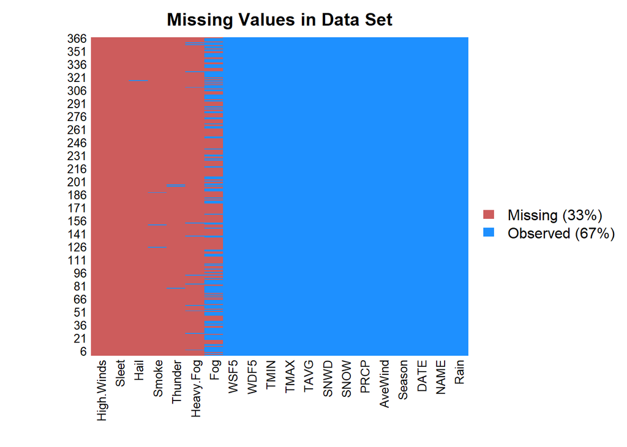

```r
missmap(rain_data, main="Missing Values in Data Set")
```

```r
rain_df <- subset(rain_data, select=c(1,3,4,5,7,8,9,10,11,12,13))
head(rain_df)
```

```
##   Rain       DATE Season AveWind SNOW SNWD TAVG TMAX TMIN WDF5 WSF5
## 1    0 01/01/2016 Winter    4.92    0    0   36   46   28   70 13.0
## 2    0 02/01/2016 Winter    5.59    0    0   33   42   25  110 29.1
## 3    1 03/01/2016 Winter    9.17    0    0   37   40   31  110 36.9
## 4    1 04/01/2016 Winter    7.61    0    0   36   38   35   10 17.0
## 5    1 05/01/2016 Winter    5.37    0    0   38   46   36   80 18.1
## 6    0 06/01/2016 Winter    6.49    0    0   44   53   37  100 16.1
```

Verifiquemos ahora si nuestro set de datos tiene valores “NA”. Una de las maneras mas comunes de tratar esto es excluir las filas que contienen valores “NA”s, o ajustar el valor faltante: media, mediana de cada columna, etc. Una alternativa más elegante consiste utilizar la función **mice()** del paquete mice (Imputación con RandomForest).

```r
sapply(rain_df, function(x) sum(is.na(x)))
```

```
##    Rain    DATE  Season AveWind    SNOW    SNWD    TAVG    TMAX    TMIN
##       0       0       0       0       0       0       0       0       0
##    WDF5    WSF5
##       0       0
```

Vemos que no tenemos valores NA.

# Exercise 3: Categorization of Variables

```r
# a.
rain_df$Rain <- factor(rain_df$Rain)
rain_df$Season <- factor(rain_df$Season, ordered = FALSE)

# Contrasts
contrasts(rain_df$Rain)
```

```
##   1
## 0 0
## 1 1
```

```r
contrasts(rain_df$Season)
```

```
##        Spring Summer Winter
## Fall        0      0      0
## Spring      1      0      0
## Summer      0      1      0
## Winter      0      0      1
```

```r
# b.
rain_df$DATE <- as.Date(rain_df$DATE,'%m/%d/%Y')

str(rain_df)
```

```
## 'data.frame':    366 obs. of  11 variables:
##  $ Rain   : Factor w/ 2 levels "0","1": 1 1 2 2 2 1 1 1 1 1 ...
##  $ DATE   : Date, format: "2016-01-01" "2016-02-01" ...
##  $ Season : Factor w/ 4 levels "Fall","Spring",..: 4 4 4 4 4 4 4 4 4 4 ...
##  $ AveWind: num  4.92 5.59 9.17 7.61 5.37 6.49 2.91 1.57 2.91 8.05 ...
##  $ SNOW   : num  0 0 0 0 0 0 0 0 0 0 ...
##  $ SNWD   : int  0 0 0 0 0 0 0 0 0 0 ...
##  $ TAVG   : int  36 33 37 36 38 44 41 42 39 43 ...
##  $ TMAX   : int  46 42 40 38 46 53 44 48 49 52 ...
##  $ TMIN   : int  28 25 31 35 36 37 34 36 30 38 ...
##  $ WDF5   : int  70 110 110 10 80 100 20 120 130 110 ...
##  $ WSF5   : num  13 29.1 36.9 17 18.1 16.1 8.9 14.1 12.1 21.9 ...
```

# Exercise 5: K-NN with k-fold Cross Validation using **caret**

Using ML algorithms for Supervised prediction: K-NN with Caret package.

```r
# Change the name of Classes
rain_df$Rain <- ifelse(rain_df$Rain == 1, "Yes", "No")
rain_df$Rain <- as.factor(rain_df$Rain)
rain_df$Season <- as.factor(rain_df$Season)

# Spliting data as training and test set. Using createDataPartition() function from caret
inTrain <- createDataPartition(y = rain_df$Rain, p = 0.7, list = FALSE)
training <- rain_df[inTrain,]; testing <- rain_df[-inTrain,]
dim(training); dim(testing)
```

```
## [1] 257  11
```

```
## [1] 109  11
```

```r
table(training$Rain); table(testing$Rain)
```

```
##
##  No Yes
## 136 121
```

```
##
##  No Yes
##  58  51
```

```r
fitControl <- trainControl(# 10-fold CV
                           method = "repeatedcv",
                           number = 10,                       # number of folds
                           repeats = 3,                       # number of complete sets of folds to compute
                           classProbs = TRUE,                 # Evaluate performance using the following function
                           summaryFunction = twoClassSummary,
                           savePredictions = T,               # for ROC
                           allowParallel = TRUE               # Parallel processing
                           )

# Logistic Regression
knn.fit <- train(Rain ~ Season+TMAX+TMIN+WSF5,
                data = training,
                preProc = c("center", "scale"),
                method = "knn",
                metric = "ROC",                               # Specify which metric to optimize
                tuneLength = 10,
                trControl = fitControl
                )

# Print results
print(knn.fit, digits = 3)
```

```
## k-Nearest Neighbors
##
## 257 samples
##   4 predictor
##   2 classes: 'No', 'Yes'
##
## Pre-processing: centered (6), scaled (6)
## Resampling: Cross-Validated (10 fold, repeated 3 times)
## Summary of sample sizes: 232, 232, 231, 231, 231, 232, ...
## Resampling results across tuning parameters:
##
##   k   ROC    Sens   Spec
##    5  0.805  0.736  0.714
##    7  0.814  0.729  0.725
##    9  0.815  0.707  0.706
##   11  0.823  0.722  0.714
##   13  0.821  0.717  0.709
##   15  0.820  0.720  0.692
##   17  0.816  0.722  0.706
##   19  0.815  0.722  0.709
##   21  0.813  0.720  0.722
##   23  0.809  0.720  0.728
##
## ROC was used to select the optimal model using the largest value.
## The final value used for the model was k = 11.
```

```r
print(knn.fit$finalModel, digits=3)
```

```
## 11-nearest neighbor model
## Training set outcome distribution:
##
##  No Yes
## 136 121
```

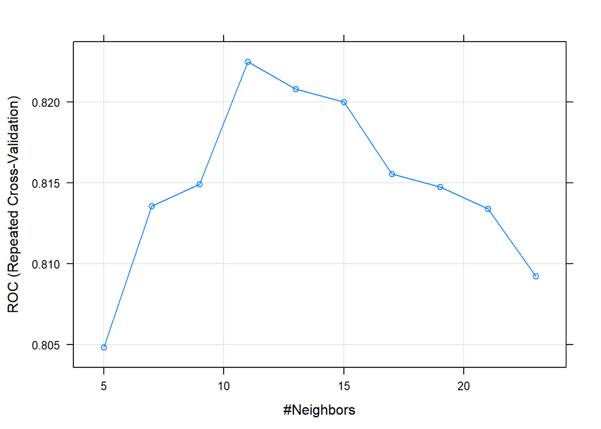

```r
# Plotting yields Number of Neighbours Vs accuracy (based on repeated cross validation)
plot(knn.fit)
```

```r
# Model Performance: get the confusion matrix to see accuracy value and other parameter values
pred <- predict(knn.fit, newdata = testing)
confusionMatrix(pred, testing$Rain, positive = "Yes")
```

```
## Confusion Matrix and Statistics
##
##           Reference
## Prediction No Yes
##        No  47  14
##        Yes 11  37
##
##                Accuracy : 0.7706
##                  95% CI : (0.6803, 0.8457)
##     No Information Rate : 0.5321
##     P-Value [Acc > NIR] : 2.28e-07
##
##                   Kappa : 0.5377
##  Mcnemar's Test P-Value : 0.6892
##
##             Sensitivity : 0.7255
##             Specificity : 0.8103
##          Pos Pred Value : 0.7708
##          Neg Pred Value : 0.7705
##              Prevalence : 0.4679
##          Detection Rate : 0.3394
##    Detection Prevalence : 0.4404
##       Balanced Accuracy : 0.7679
##
##        'Positive' Class : Yes
##
```

```r
# Plot the ROC Curve and overall AUC
#knnPredict <- predict(knn.fit, newdata = testing, type="raw")
#ROCRPred <- prediction(knnPredict, testing$Rain)
#ROCRperf <- performance(ROCRPred, measure='tpr', x.measure='fpr')

# Plot the ROC Curve
#plot(ROCRperf, colorize=TRUE)
#abline(0, 1, lty = 2)

# Calculate the Area under curve(AUC)
#AUC <- auc(test$Rain, predicted)
#AUC
```

# Exercise 6: Visualization

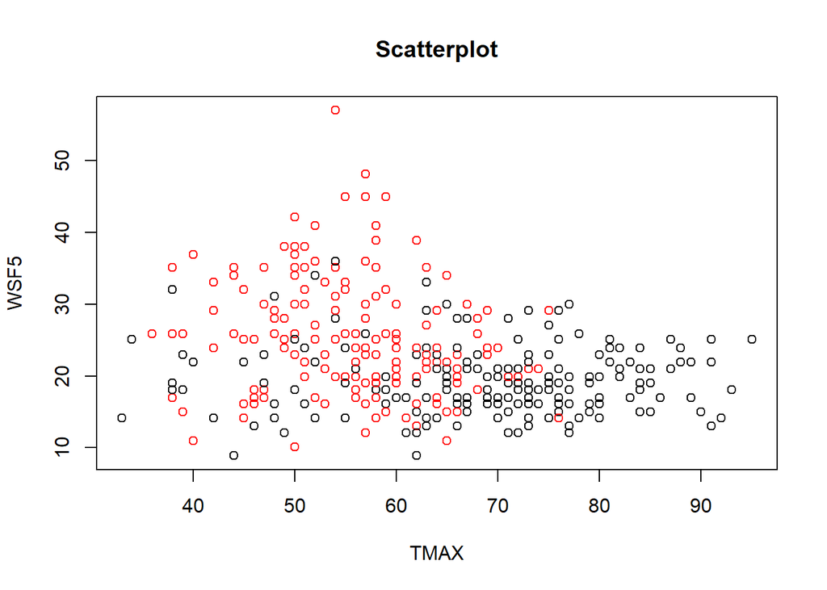

```r
# decisionplot function
# source: http://michael.hahsler.net/SMU/EMIS7332/R/viz_classifier.html

decisionplot <- function(model, data, class = NULL, predict_type = "class",
  resolution = 100, showgrid = TRUE, ...) {

  if(!is.null(class)) cl <- data[,class] else cl <- 1
  data <- data[,1:2]
  k <- length(unique(cl))

  plot(data, col = as.integer(cl)+1L, pch = as.integer(cl)+1L, ...)

  # make grid
  r <- sapply(data, range, na.rm = TRUE)
  xs <- seq(r[1,1], r[2,1], length.out = resolution)
  ys <- seq(r[1,2], r[2,2], length.out = resolution)
  g <- cbind(rep(xs, each=resolution), rep(ys, time = resolution))
  colnames(g) <- colnames(r)
  g <- as.data.frame(g)

  ### guess how to get class labels from predict
  ### (unfortunately not very consistent between models)
  p <- predict(model, g, type = predict_type)
  if(is.list(p)) p <- p$class
  p <- as.factor(p)

  if(showgrid) points(g, col = as.integer(p)+1L, pch = ".")

  z <- matrix(as.integer(p), nrow = resolution, byrow = TRUE)
  contour(xs, ys, z, add = TRUE, drawlabels = FALSE,
    lwd = 2, levels = (1:(k-1))+.5)

  invisible(z)
}




# Data Subset
rain_df.sub <- subset(rain_df, select=c(TMAX, WSF5, Rain))

# Plot XY
plot(rain_df.sub[, 1:2], col = rain_df.sub[, 3], main = "Scatterplot")
```

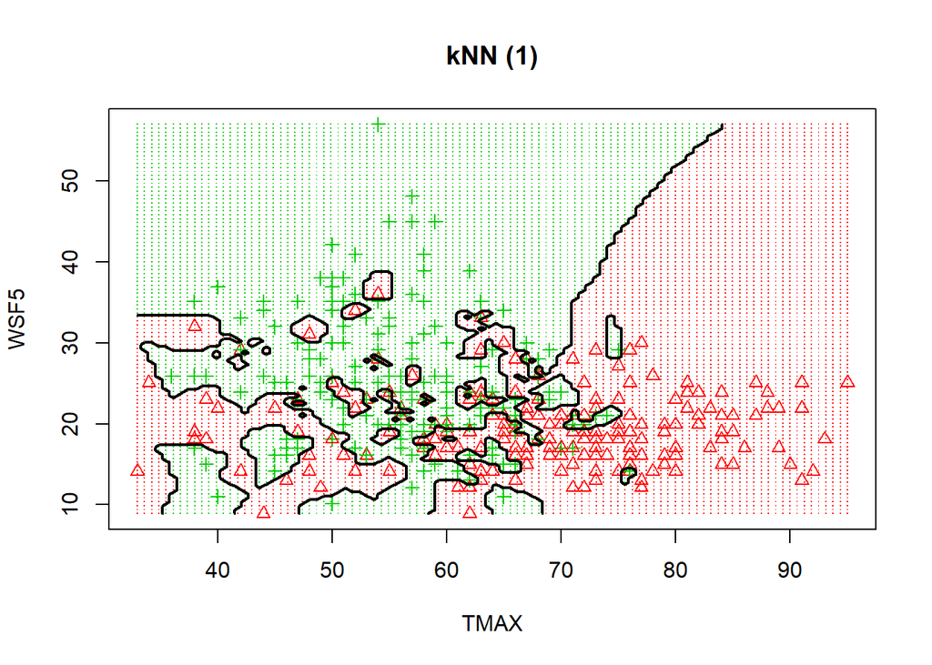

```r
# K-NN fit (k=1)
knn3.fit1 <- knn3(Rain ~ TMAX+WSF5, data = rain_df.sub, k = 1)
# Plot K-NN fit (k=1)
decisionplot(knn3.fit1, rain_df.sub, class = "Rain", main = "kNN (1)")
```

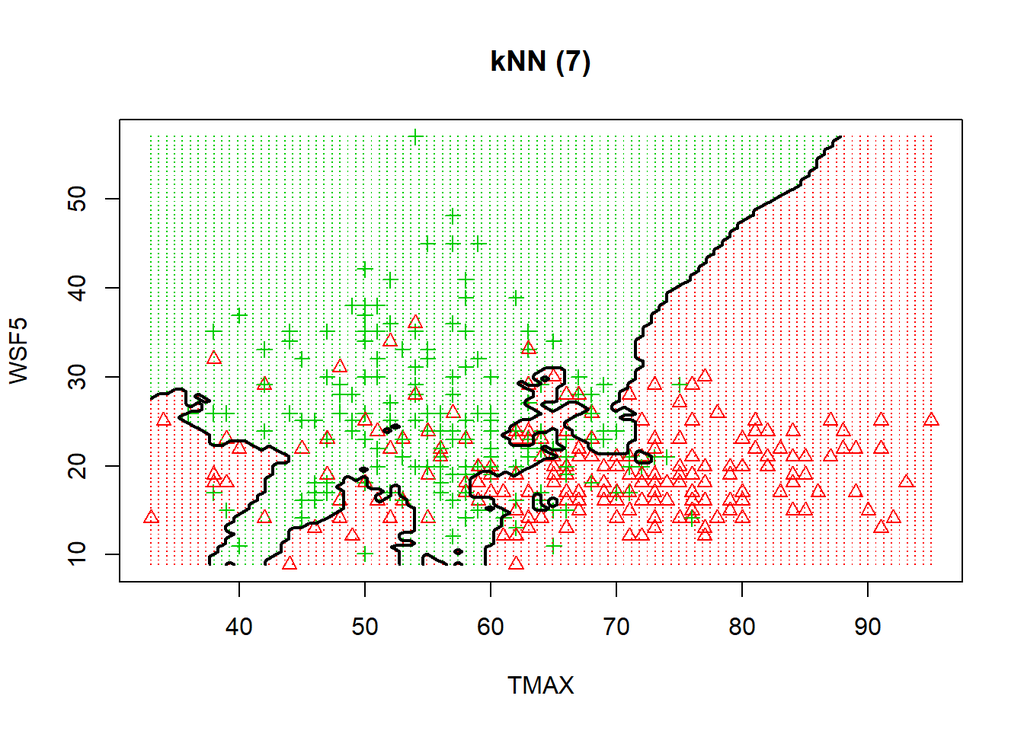

```r
# K-NN fit (k=7)
knn3.fit7 <- knn3(Rain ~ TMAX+WSF5, data = rain_df.sub, k = 7)
# Plot K-NN fit (k=7)
decisionplot(knn3.fit7, rain_df.sub, class = "Rain", main = "kNN (7)")
```